# MB Assessed Practical 2

Thomas Holland (th675)

# Question 1

*Why do we only need to analyse two differential equations even though the model has three variables (S, I and R)?*

We only need to analyse two differential equations because the third variable, R, is a function of the other two variables. In this case, R is a function of S and I, and can be calculated as R = 1 - S - I. This means that we can calculate R from S and I, and therefore only need to analyse two differential equations.

# Question 2

*Write a function R0(beta,gamma,N) which takes three arguments (β, γ and the population size N ) and returns the basic reproductive number R0 = βN/γ. Then write code to generate a plot of R0 against the recovery rate γ ranging from 0.2 to 4, with fixed values β = 0.02 and N = 100. Using the abline function, add a horizontal line to show the threshold R0 = 1 on the same plot.*

```r
# dynamics of the simple epidemic model (SIR)
# S' = -beta*S*I
# I' = beta*S*I - gamma*I

# function to calculate R0
R0 <- function(beta, gamma, N) {
    return(beta*N/gamma)
}
```

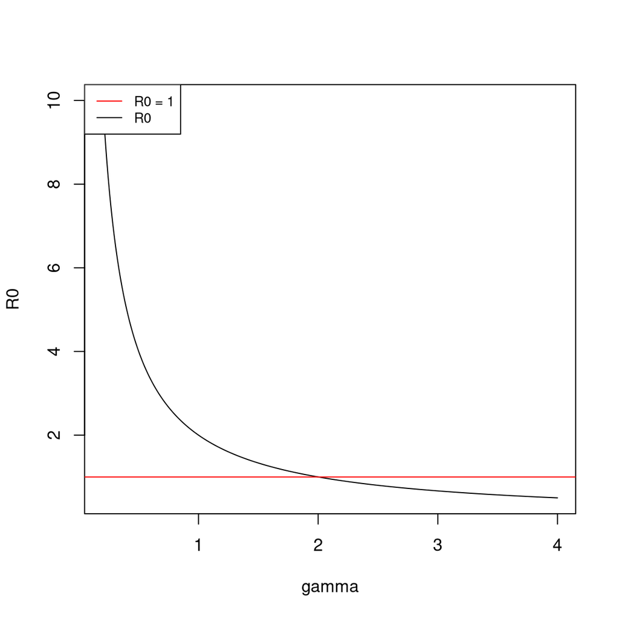

```r
# plot R0 against gamma
gamma <- seq(0.2, 4, length.out = 10000)
R0 <- R0(0.02, gamma, 100)
plot(gamma, R0, type = "l", xlab = "gamma", ylab = "R0")
abline(h = 1, col = "red")
# labels for the lines
legend("topleft", legend = c("R0 = 1", "R0"), col = c("red", "black"), lty = 1, cex = 0.8)
```

# Question 3

*Write a function SIR_dydt(t,y,parms) which takes three arguments (time t, current values of the variables, and values of the model parameters) and returns a list whose only element is a vector with the values of the derivatives dS/dt and dI/dt (see Practical 15). Before trying to solve the model, follow these steps test that your SIR_dydt function works correctly. According to the model definition, dS/dt should always be negative, whereas dI/dt will only be positive if βS > γ and I > 0.*

```r
# function to calculate the derivatives of S and I
SIR_dydt <- function(t, y, parms) {
    with(as.list(c(y, parms)), {
        dS <- -beta*S*I
        dI <- beta*S*I - gamma*I
        return(list(c(dS, dI)))
    })
}
```

```r
# test the function
# dS/dt should be negative, and dI/dt should be positive
SIR_dydt(0, c(S = 0.9, I = 0.1), c(beta = 0.02, gamma = 1))
```

```
## [[1]]
## [1] -0.0018 -0.0982
```

```r
# test the function with I = 0
# dS/dt should be negative, and dI/dt should be 0
SIR_dydt(0, c(S = 0.9, I = 0), c(beta = 0.02, gamma = 1))
```

```
## [[1]]
## [1] 0 0
```

```r
# test the function with beta*S > gamma
# dS/dt should be negative, and dI/dt should be positive
SIR_dydt(0, c(S = 0.9, I = 0.1), c(beta = 1, gamma = 0.02))
```

```
## [[1]]
## [1] -0.090  0.088
```

## Part (a)

*Setting β = 0.02, γ = 1, I = 1, write a for loop that prints the value of dI/dt for S ranging from 10 to 80 in steps of 10.*

```r
# for loop to print dI/dt for S ranging from 10 to 80 in steps of 10
# format list to print as kable, where columns are S, dI/dt and each row is a different value of S

# create a data frame to store the results
results <- data.frame(S = numeric(), dI_dt = numeric())

for (S in seq(10, 80, by = 10)) {
    # calculate dI/dt
    dI_dt <- SIR_dydt(0, c(S = S, I = 1), c(beta = 0.02, gamma = 1))[[1]][2]
    # add the result to the list
    results <- rbind(results, data.frame(S = S, dI_dt = dI_dt))
}

# print the results as a kable
kable(results)
```

| S | dI_dt |
| --- | --- |
| 10 | -0.8 |
| 20 | -0.6 |
| 30 | -0.4 |
| 40 | -0.2 |
| 50 | 0.0 |
| 60 | 0.2 |
| 70 | 0.4 |
| 80 | 0.6 |

## Part (b)

*Based on the last output, what is the critical density of susceptible individuals required for an epidemic?*

The critical density of susceptible individuals required for an epidemic is above 50%. This is because when S is below 50%, dI/dt is negative, and therefore the number of infected individuals decreases. When S is above 50%, dI/dt is positive, and therefore the number of infected individuals increases.

# Question 4

*Using the function ode() from the deSolve package, compute the solution of the SIR model with N = 100, β = 0.02, γ = 1, initial conditions S(0) = 99.9, I(0) = 0.1, and a vector of time points ranging from 0 to 20. Plot the solution in the (S,I) phase plane.*

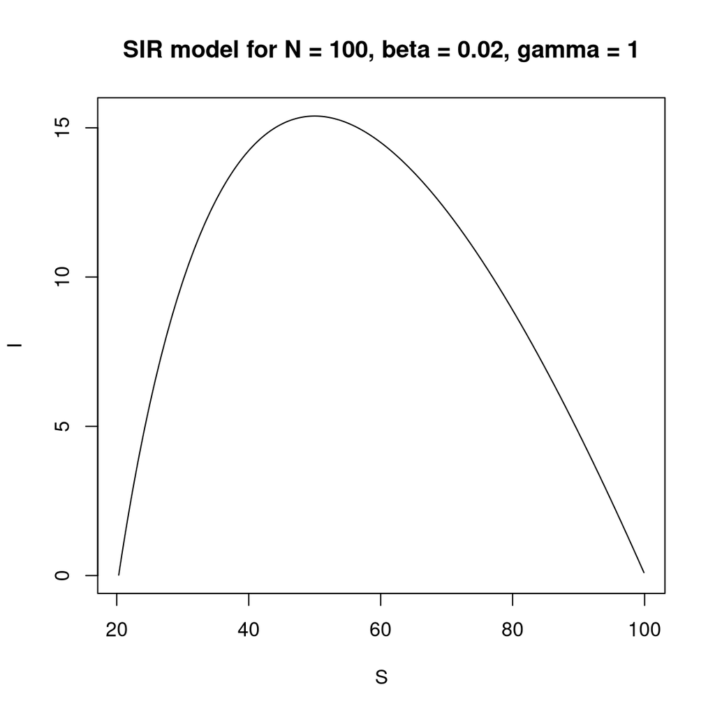

```r
# solve the SIR model
# initial conditions
S0 <- 99.9
I0 <- 0.1
# parameters
N <- 100
beta <- 0.02
gamma <- 1
# time points
t <- seq(0, 20, length.out = 10000)

# solve the model
out <- ode(y = c(S = S0, I = I0), times = t, func = SIR_dydt, parms = c(beta = beta, gamma = gamma))

# plot the solution in the (S,I) phase plane with title
plot(out[, "S"], out[, "I"], type = "l", xlab = "S", ylab = "I", main = "SIR model for N = 100, beta = 0.02, gamma = 1")
```

# Question 5

*Create a vector containing the number of recovered individuals R(t) at the same time points as in the previous question. Plot all three variables (S, I and R) against time, using different colours.*

```r
# calculate the number of recovered individuals and add to the out data frame
out <- cbind(out, R = N - out[, "S"] - out[, "I"])
out <- as(data.frame(out), "data.frame")
kable(head(out))
```

| time | S | I | R |
| --- | --- | --- | --- |
| 0.0000000 | 99.90000 | 0.1000000 | 0.0000000 |
| 0.0020002 | 99.89960 | 0.1001998 | 0.0002002 |
| 0.0040004 | 99.89920 | 0.1004000 | 0.0004008 |
| 0.0060006 | 99.89880 | 0.1006006 | 0.0006019 |
| 0.0080008 | 99.89840 | 0.1008017 | 0.0008033 |
| 0.0100010 | 99.89799 | 0.1010031 | 0.0010051 |

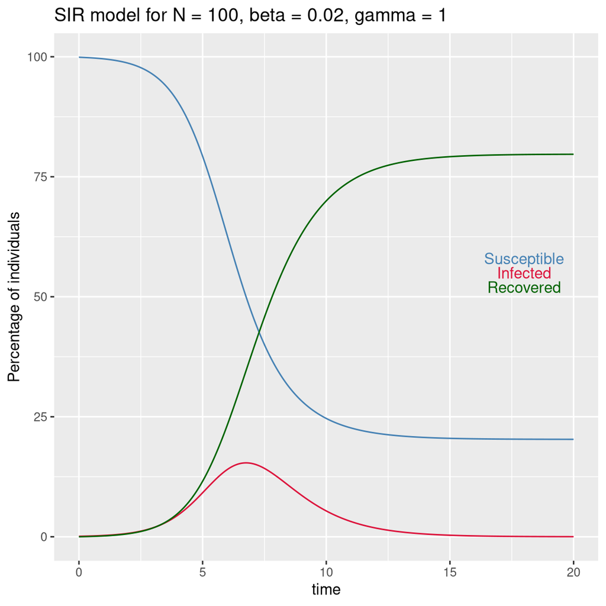

```r
# plot S, I and R against time
ggplot(data = out, aes(x = time)) +
    geom_line(aes(y = S), colour = "#4682B4", label = "Susceptible") +
    geom_line(aes(y = I), colour = "#DC143C", label = "Infected") +
    geom_line(aes(y = R), colour = "#006400", label = "Recovered") +
    labs(x = "time", y = "Percentage of individuals", title = "SIR model for N = 100, beta = 0.02, gamma = 1") +
    theme(legend.position = "bottom") +
    annotate("text", x = 18, y = 58, label = "Susceptible", colour = "#4682B4") +
    annotate("text", x = 18, y = 55, label = "Infected", colour = "#DC143C") +
    annotate("text", x = 18, y = 52, label = "Recovered", colour = "#006400")
```

# Question 6

*This question aims to estimate the final epidemic size f , defined as the proportion of the population that gets infected. Recall from lecture 5 (Epidemic models) that f is the non-zero solution of the following equation:*

$$1-f-e^{-\mathcal{R}_0 \cdot
f}=0$$

## Part (a)

*Write a function fes_eq(f,r0) which calculates the left-hand-side of the equation for any values of $f$ and $\mathcal{R}_0$.*

```r
# function to calculate the left-hand-side of the equation for any values of f and R0
fes_eq <- function(f, r0) {
    1 - f - exp(-r0 * f)
}
```

```r
# test the function
fes_eq(0.1, 2)
```

```
## [1] 0.08126925
```

## Part (b)

*Setting $\mathcal{R}_0=2$, plot the left-hand side of the equation against $f$ , for $f$ ranging from 0 to 1.*

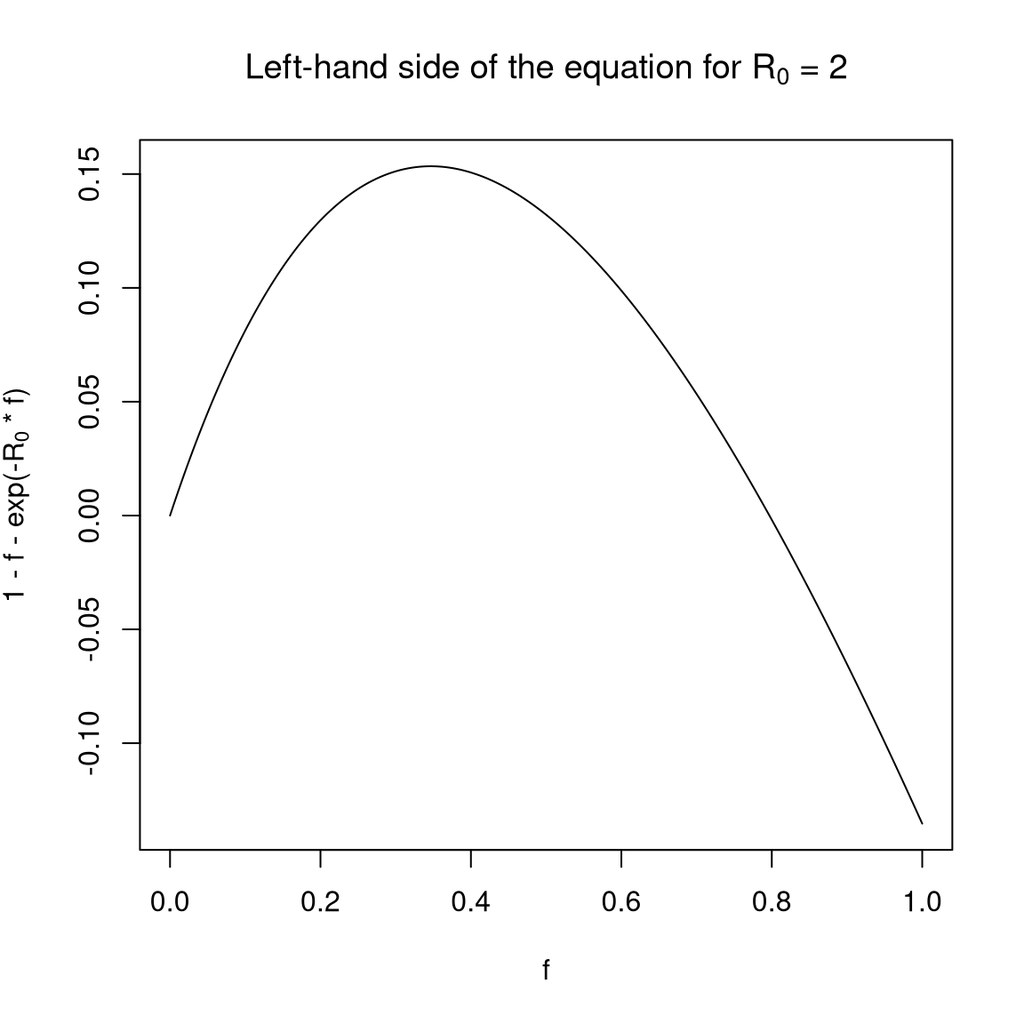

```r
# plot the left-hand side of the equation against f, for f ranging from 0 to 1
f <- seq(0, 1, length.out = 10000)
plot(f, fes_eq(f, 2), type = "l", xlab = "f", ylab = expression(paste("1 - f - exp(-", R[0], " * f)")), main = expression(paste("Left-hand side of the equation for ", R[0], " = 2")))
```

## Part (c)

*Setting R0 = 2, write a while() loop that goes through values of f from 1 downwards in steps of 0.001, stopping when fes_eq(f,r0) >= 0. What is the final epidemic size for R0 = 2?*

```r
# while loop to go through values of f from 1 downwards in steps of 0.001, stopping when fes_eq(f,r0) >= 0
# print the final epidemic size for R0 = 2

# set R0
R0 <- 2
# set f to 1
f <- 1
# while loop

while (fes_eq(f, R0) < 0) {
    f <- f - 0.001
}

# print the final epidemic size for R0 = 2
print(f)
```

```
## [1] 0.796
```

## Part (d)

Using your code from questions (a) and (c), write a function fes_sol(r0) which returns the value of the final epidemic size f for any given value of $\mathcal{R}_0$.

```r
# function to return the value of the final epidemic size f for any given value of R0
fes_sol <- function(r0) {
    # set f to 1
    f <- 1
    # while loop
    while (fes_eq(f, r0) < 0) {
        # this will fail when R0 = 1 as fes_eq(f, r0) will always be negative
        f <- f - 0.001
    }
    # return the final epidemic size
    return(f)
}
```

```r
# test the function
fes_sol(2)
```

```
## [1] 0.796
```

## Part (e)

*Plot the final epidemic size as a function of R0, for R0 ranging from 1.1 to 6. You should obtain a graph similar to Figure 5.5 in the Lecture notes. (Note that function fes_sol will fail for R0 = 1).*

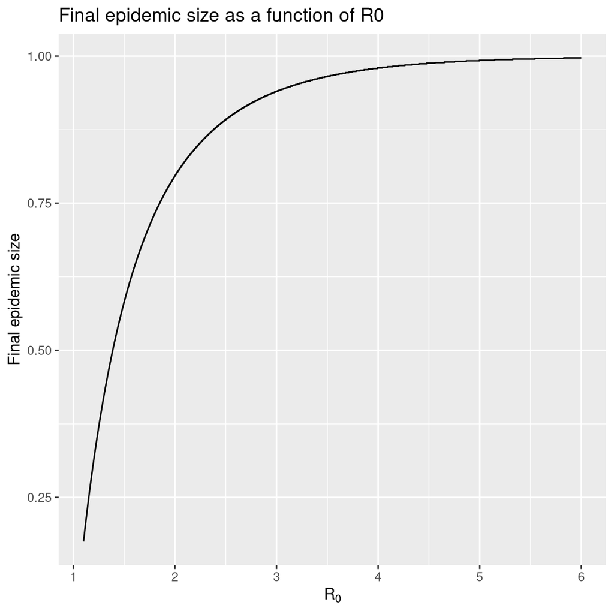

```r
# plot the final epidemic size as a function of R0, for R0 ranging from 1.1 to 6
# set R0
R0 <- seq(1.1, 6, length.out = 10000)
# calculate the final epidemic size
for (i in 1:length(R0)) {
    f[i] <- fes_sol(R0[i])
}
# combine to dataframe
df <- data.frame(R0, f)
# plot
ggplot(data = df, aes(x = R0, y = f)) +
    geom_line() +
    labs(x = expression(R[0]), y = "Final epidemic size", title = "Final epidemic size as a function of R0")
```